# Super_Store

2022-04-13

## Super Store Analysis

Super Store is a small business located in the United States of American. They sell Furniture, Office Supplies and Technology Product and their customers are the mass Consumer, Corporate and Home Offices. My task is to analyze and identify opportunities for Super Store to boost business growth.

First we import all the libraries, this are all the libraries i used

- install.packages(tidyverse)
- install.packages(RColorBrewer)
- install.packages(ggfortify) –convert time series data to a data_Frame
- install.packages(doBy) –To use the order_BY function
- install.packages(plyr)
- install.packages(skimr)
- install.packages(janitor)

# Loading of all the library to be used

```r
library(tidyverse)
library(RColorBrewer)
library(ggfortify)
library(doBy)
library(plyr)
library(skimr)
library(janitor)
library(scales)
```

## Super Store Exploratory

After installing and loading of my library let see some analysis in our super store dataset

# Loading the dataset

```r
super_store<-read.csv("SuperStore.csv")
```

# getting the summarization of all the data in super store

```r
skim_without_charts(super_store)
```

Data summary

| Name | super_store |
| --- | --- |
| Number of rows | 9994 |
| Number of columns | 21 |
| _______________________ |  |
| Column type frequency: |  |
| character | 15 |
| numeric | 6 |
| ________________________ |  |
| Group variables | None |

**Variable type: character**

| skim_variable | n_missing | complete_rate | min | max | empty | n_unique | whitespace |
| --- | --- | --- | --- | --- | --- | --- | --- |
| Order.ID | 0 | 1 | 14 | 14 | 0 | 5009 | 0 |
| Order.Date | 0 | 1 | 8 | 9 | 0 | 1236 | 0 |
| Ship.Date | 0 | 1 | 8 | 9 | 0 | 1334 | 0 |
| Ship.Mode | 0 | 1 | 8 | 14 | 0 | 4 | 0 |
| Customer.ID | 0 | 1 | 8 | 8 | 0 | 793 | 0 |
| Customer.Name | 0 | 1 | 7 | 22 | 0 | 793 | 0 |
| Segment | 0 | 1 | 8 | 11 | 0 | 3 | 0 |
| Country.Region | 0 | 1 | 13 | 13 | 0 | 1 | 0 |
| City | 0 | 1 | 4 | 17 | 0 | 531 | 0 |
| State | 0 | 1 | 4 | 20 | 0 | 49 | 0 |
| Region | 0 | 1 | 4 | 7 | 0 | 4 | 0 |
| Product.ID | 0 | 1 | 15 | 15 | 0 | 1862 | 0 |
| Category | 0 | 1 | 9 | 15 | 0 | 3 | 0 |
| Sub.Category | 0 | 1 | 3 | 11 | 0 | 17 | 0 |
| Product.Name | 0 | 1 | 5 | 127 | 0 | 1850 | 0 |

**Variable type: numeric**

| skim_variable | n_missing | complete_rate | mean | sd | p0 | p25 | p50 | p75 | p100 |
| --- | --- | --- | --- | --- | --- | --- | --- | --- | --- |
| Row.ID | 0 | 1 | 4997.50 | 2885.16 | 1.00 | 2499.25 | 4997.50 | 7495.75 | 9994.00 |
| Postal.Code | 11 | 1 | 55245.23 | 32038.72 | 1040.00 | 23223.00 | 57103.00 | 90008.00 | 99301.00 |
| Sales | 0 | 1 | 229.86 | 623.25 | 0.44 | 17.28 | 54.49 | 209.94 | 22638.48 |
| Quantity | 0 | 1 | 3.79 | 2.23 | 1.00 | 2.00 | 3.00 | 5.00 | 14.00 |
| Discount | 0 | 1 | 0.16 | 0.21 | 0.00 | 0.00 | 0.20 | 0.20 | 0.80 |
| Profit | 0 | 1 | 28.66 | 234.26 | -6599.98 | 1.73 | 8.67 | 29.36 | 8399.98 |

#Testing for missing values

```r
missing <- sapply(super_store, function(x) sum(is.na(x)))
missing
```

```
##         Row.ID       Order.ID     Order.Date      Ship.Date      Ship.Mode
##              0              0              0              0              0
##    Customer.ID  Customer.Name        Segment Country.Region           City
##              0              0              0              0              0
##          State    Postal.Code         Region     Product.ID       Category
##              0             11              0              0              0
##   Sub.Category   Product.Name          Sales       Quantity       Discount
##              0              0              0              0              0
##         Profit
##              0
```

# Checking for the structure of our super stire dataset

```r
str(super_store)
```

```
## 'data.frame':    9994 obs. of  21 variables:
##  $ Row.ID        : int  1 2 3 4 5 6 7 8 9 10 ...
##  $ Order.ID      : chr  "CA-2018-152156" "CA-2018-152156" "CA-2018-138688" "US-2017-108966" ...
##  $ Order.Date    : chr  "8-Nov-18" "8-Nov-18" "12-Jun-18" "11-Oct-17" ...
##  $ Ship.Date     : chr  "11-Nov-18" "11-Nov-18" "16-Jun-18" "18-Oct-17" ...
##  $ Ship.Mode     : chr  "Second Class" "Second Class" "Second Class" "Standard Class" ...
##  $ Customer.ID   : chr  "CG-12520" "CG-12520" "DV-13045" "SO-20335" ...
##  $ Customer.Name : chr  "Claire Gute" "Claire Gute" "Darrin Van Huff" "Sean O'Donnell" ...
##  $ Segment       : chr  "Consumer" "Consumer" "Corporate" "Consumer" ...
##  $ Country.Region: chr  "United States" "United States" "United States" "United States" ...
##  $ City          : chr  "Henderson" "Henderson" "Los Angeles" "Fort Lauderdale" ...
##  $ State         : chr  "Kentucky" "Kentucky" "California" "Florida" ...
##  $ Postal.Code   : int  42420 42420 90036 33311 33311 90032 90032 90032 90032 90032 ...
##  $ Region        : chr  "South" "South" "West" "South" ...
##  $ Product.ID    : chr  "FUR-BO-10001798" "FUR-CH-10000454" "OFF-LA-10000240" "FUR-TA-10000577" ...
##  $ Category      : chr  "Furniture" "Furniture" "Office Supplies" "Furniture" ...
##  $ Sub.Category  : chr  "Bookcases" "Chairs" "Labels" "Tables" ...
##  $ Product.Name  : chr  "Bush Somerset Collection Bookcase" "Hon Deluxe Fabric Upholstered Stacking Chairs, Rounded Back" "Self-Adhesive Address Labels for Typewriters by Universal" "Bretford CR4500 Series Slim Rectangular Table" ...
##  $ Sales         : num  262 731.9 14.6 957.6 22.4 ...
##  $ Quantity      : int  2 3 2 5 2 7 4 6 3 5 ...
##  $ Discount      : num  0 0 0 0.45 0.2 0 0 0.2 0.2 0 ...
##  $ Profit        : num  41.91 219.58 6.87 -383.03 2.52 ...
```

# Transactions per customer

```r
customers<- aggregate(super_store$Customer.Name, by=list(super_store$Customer.Name), FUN=length)
colnames(customers)<-c("Customer","Count")
head(customers)
```

```
##             Customer Count
## 1      Aaron Bergman     6
## 2      Aaron Hawkins    11
## 3     Aaron Smayling    10
## 4    Adam Bellavance    18
## 5          Adam Hart    20
## 6 Adam Shillingsburg    25
```

# ploting the graph for trancsaction per customer

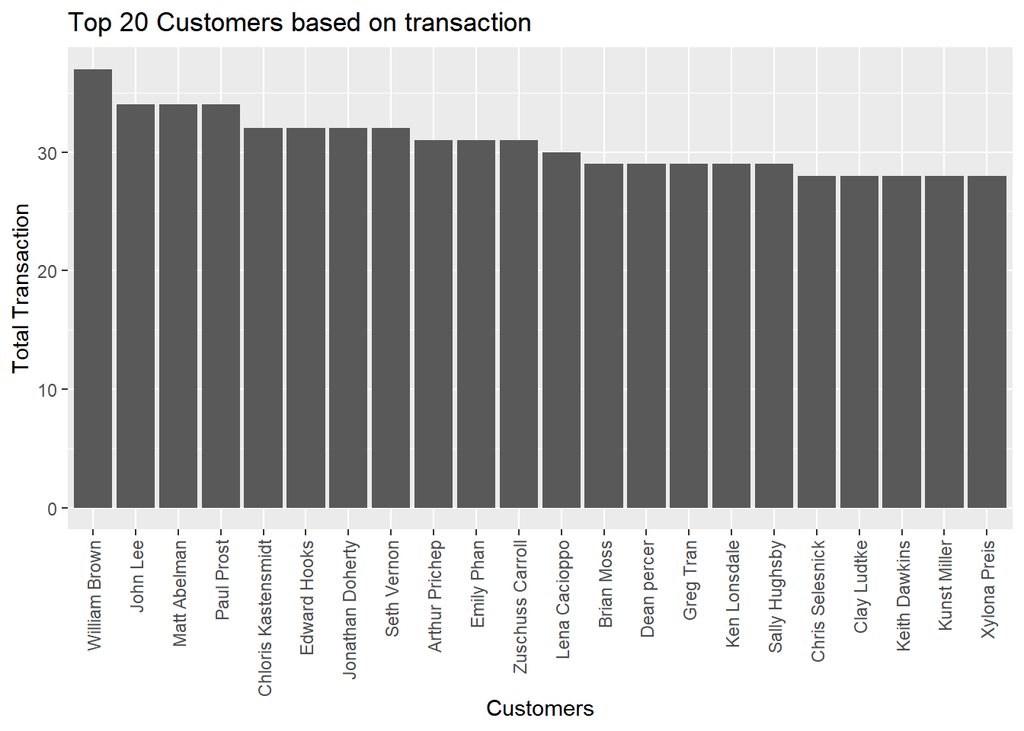

# Profitability by customer

```r
store_profits <- aggregate(super_store$Profit, by=list(Category=super_store$Customer.Name), FUN=sum)
colnames(store_profits)<-c("Customer","profit")
head(store_profits)
```

```
##             Customer    profit
## 1      Aaron Bergman  129.3465
## 2      Aaron Hawkins  365.2152
## 3     Aaron Smayling -253.5746
## 4    Adam Bellavance 2054.5885
## 5          Adam Hart  281.1890
## 6 Adam Shillingsburg   64.5374
```

# ploting the graph for higest profit per customer

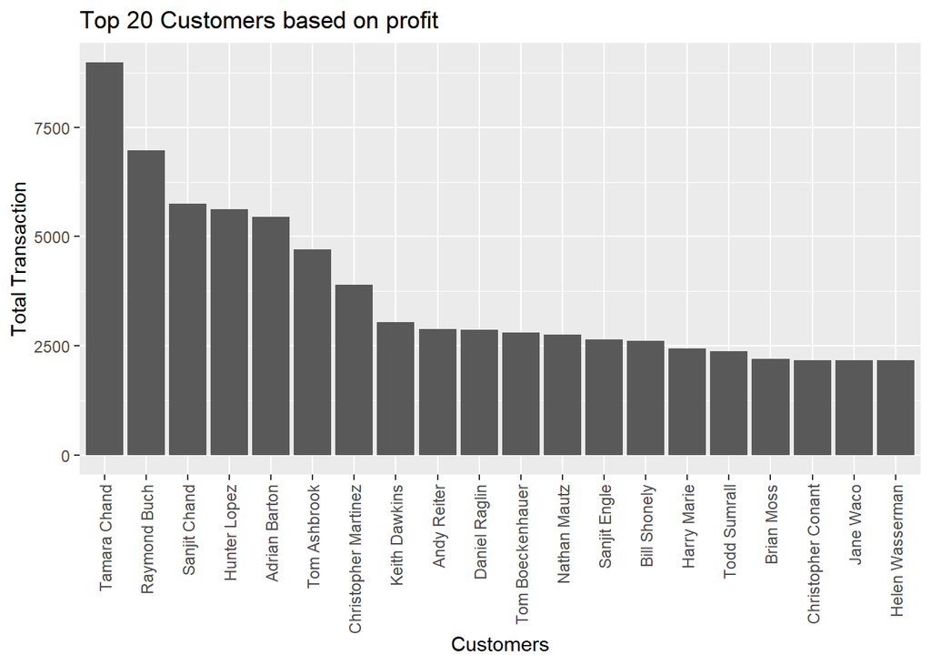

##Number of orders from each city

```r
citypop <- aggregate(super_store$City, by=list(super_store$City), FUN=length)
colnames(citypop)<-c("City","Count")
head(citypop)
```

```
##          City Count
## 1    Aberdeen     1
## 2     Abilene     1
## 3       Akron    21
## 4 Albuquerque    14
## 5  Alexandria    16
## 6       Allen     4
```

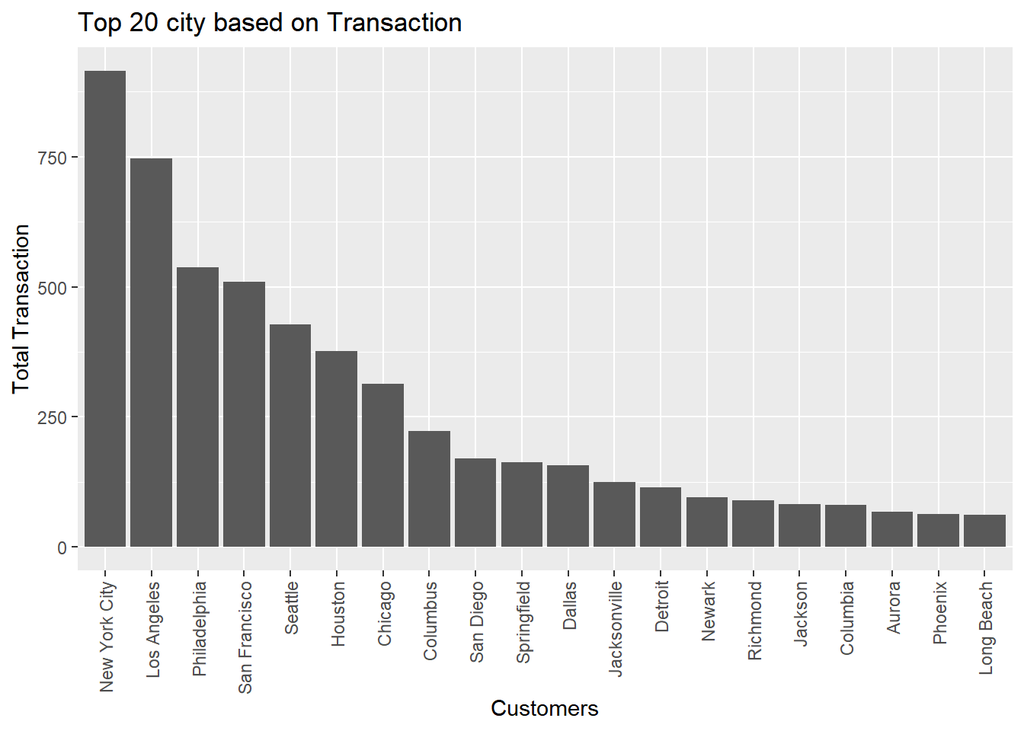

## Total Profit from each city

```r
citypor <- aggregate(super_store$Profit, by=list(super_store$City), FUN=sum)
colnames(citypor)<-c("City","profit")
head(citypor)
```

```
##          City    profit
## 1    Aberdeen    6.6300
## 2     Abilene   -3.7584
## 3       Akron -186.6356
## 4 Albuquerque  634.0881
## 5  Alexandria  318.6183
## 6       Allen  -39.8775
```

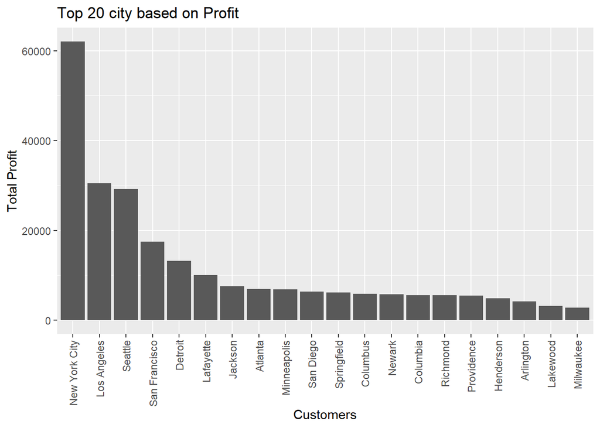